# Data Replication Project

Salma Ghazi, Shana Mandelbaum

2024-06-24

# Description

Replicated figure 4, table 3, figures 2 and 3, and table 4 from https://static1.squarespace.com/static/5ac4569925bf02b3f05a651f/t/638b509cb141756009541e29/1670074524751/Immigration_Paper_V2-1.pdf using only google trends data (without the bing portion)

# Replication

This paper studies the effect that the media has on people looking for ways to report immigrants (through their internet searches)

## Download Google Trends Data + Format

```r
reporting_data <- read_csv("data/Google_Trends_Immigrant_Reporting.csv")
crime_data <- read_csv("data/Google_Trends_Immigrant_Crime.csv")
welfare_data <- read_csv("data/Google_Trends_Immigrant_Welfare.csv")
reporting_data <-
  reporting_data %>%
  rename(search_interest = Num_Searches) %>%
  mutate(date=parse_date(Month, "%Y-%m")) %>%
  filter(year(date) < 2020)


crime_data <-
  crime_data %>%
  rename(search_interest = Num_Searches) %>%
  mutate(date=parse_date(Month, "%Y-%m")) %>%
  filter(year(date) < 2020) %>%
  filter(search_interest != 0)


welfare_data <-
  welfare_data %>%
  rename(search_interest = Num_Searches) %>%
  mutate(date=parse_date(Month, "%Y-%m")) %>%
  filter(year(date) < 2020) %>%
  filter(search_interest != 0)
```

```r
reporting_data <-
  reporting_data %>%
  mutate(President = ifelse(year(date) < 2009, "Bush", ifelse(year(date) < 2017, "Obama", "Trump")))

crime_data <-
  crime_data %>%
  mutate(President = ifelse(year(date) < 2009, "Bush", ifelse(year(date) < 2017, "Obama", "Trump")))

welfare_data <-
  welfare_data %>%
  mutate(President = ifelse(year(date) < 2009, "Bush", ifelse(year(date) < 2017, "Obama", "Trump")))
```

## Figure 4

Figure 4 in the paper shows the search interest generated on Google trends about immigration reporting, as well as people searching about immigration in relation to welfare and crime. We see that during the Trump presidency, these numbers were usually higher than during the Bush and Obama administrations. The paper goes on to analyze media interest before and during the Trump administration to see if a correlation exists between higher reporting searches and media cues.

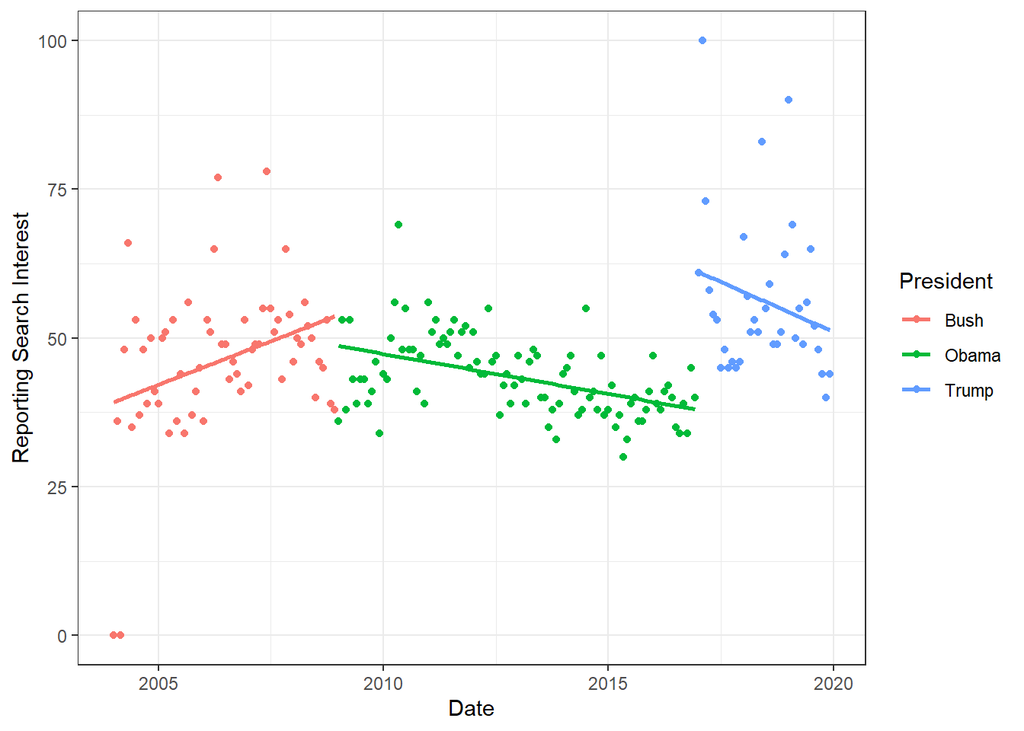

```r
reporting_data %>%
  ggplot(aes(x = date, y = search_interest, color = President)) +
  geom_point() +
  geom_smooth(method = "lm", se = F) +
  labs(x = "Date", y = "Reporting Search Interest")
```

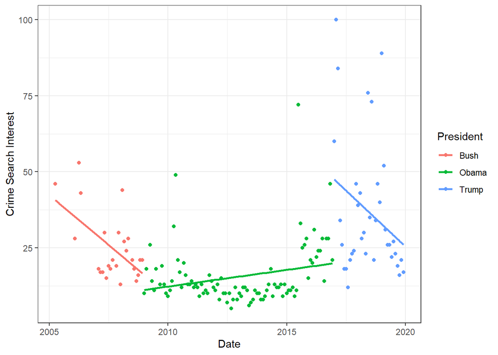

```r
crime_data %>%
  ggplot(aes(x = date, y = search_interest, color = President)) +
  geom_point() +
  geom_smooth(method = "lm", se = F) +
  labs(x = "Date", y = "Crime Search Interest")
```

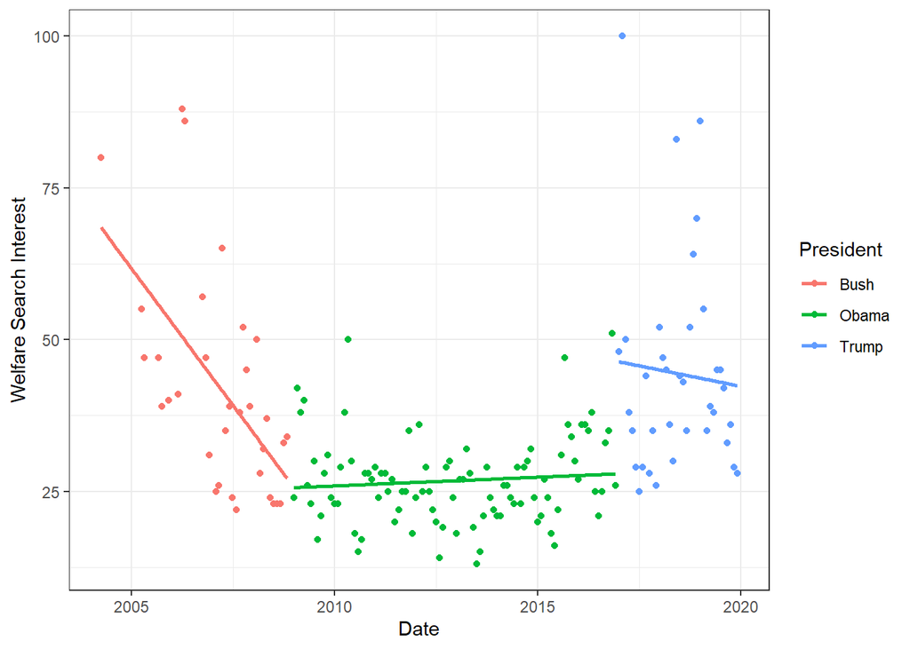

```r
welfare_data %>%
  ggplot(aes(x = date, y = search_interest, color = President)) +
  geom_point() +
  geom_smooth(method = "lm", se=F) +
  labs(x = "Date", y = "Welfare Search Interest")
```

## Table 3

Table 3 is a regression that seeks to see the effects of the date and presidential administration on reporting, crime, and welfare search interest. The results we obtain show that Trump’s presidency produced significant effects on search interest.

```r
reporting_data <-
  reporting_data %>%
  mutate(Is_Bush = (President=="Bush"), Is_Obama = (President=="Obama"), Is_Trump = (President=="Trump"))

crime_data <-
  crime_data %>%
  mutate(Is_Bush = (President=="Bush"), Is_Obama = (President=="Obama"), Is_Trump = (President=="Trump"))

welfare_data <-
  welfare_data %>%
  mutate(Is_Bush = (President=="Bush"), Is_Obama = (President=="Obama"), Is_Trump = (President=="Trump"))
```

```r
reporting_model <- lm(search_interest ~ date + Is_Bush + Is_Trump + Is_Obama , data=reporting_data)
crime_model <- lm(search_interest ~ date + Is_Bush + Is_Trump + Is_Obama , data=crime_data)
welfare_model <- lm(search_interest ~ date + Is_Bush + Is_Trump + Is_Obama , data=welfare_data)

stargazer(crime_model, welfare_model, reporting_model, type = "text",
          column.labels = c("Crime", "Welfare", "Report"))
```

```
##
## ===========================================================================================
##                                               Dependent variable:
##                     -----------------------------------------------------------------------
##                                                 search_interest
##                              Crime                  Welfare                 Report
##                               (1)                     (2)                     (3)
## -------------------------------------------------------------------------------------------
## date                         0.001                  -0.001                  -0.002
##                             (0.002)                 (0.001)                 (0.001)
##
## Is_Bush                    11.208**                12.126***                -0.977
##                             (4.513)                 (3.925)                 (3.067)
##
## Is_Trump                   19.169***               20.304***               16.289***
##                             (4.268)                 (3.781)                 (2.947)
##
## Is_Obama
##
##
## Constant                    -0.156                 47.532**                70.043***
##                            (26.035)                (22.456)                (17.008)
##
## -------------------------------------------------------------------------------------------
## Observations                  155                     165                     192
## R2                           0.289                   0.301                   0.191
## Adjusted R2                  0.275                   0.288                   0.178
## Residual Std. Error    13.956 (df = 151)       12.594 (df = 161)       10.182 (df = 188)
## F Statistic         20.471*** (df = 3; 151) 23.061*** (df = 3; 161) 14.803*** (df = 3; 188)
## ===========================================================================================
## Note:                                                           *p<0.1; **p<0.05; ***p<0.01
```

We obtained different results than the paper due to differences in our data downloaded from google trends. When given the exact data the paper used, we obtained their results

## Figures 2+3

Figure 2 plots the total number of news segments regarding the topic of immigration on three news channels across three time periods - pre campaign, campaign, and post inauguration (Trump). Figure 3 uses topics one and three from the topic model which focus on crime and topic 13 which focused on welfare to plot the proportion of segments that focused on these specific topics on the same three channels during the same time period. The media focused more on the topics of immigration post inauguration, evidently because this was a key part of President Trump’s policy. We can also see that more conservative media, such as fox news, focused on the topic of immigration more than cnn and msnbc.

```r
load("data/topic_model_lite.RData")
```

Topic Model was given to us

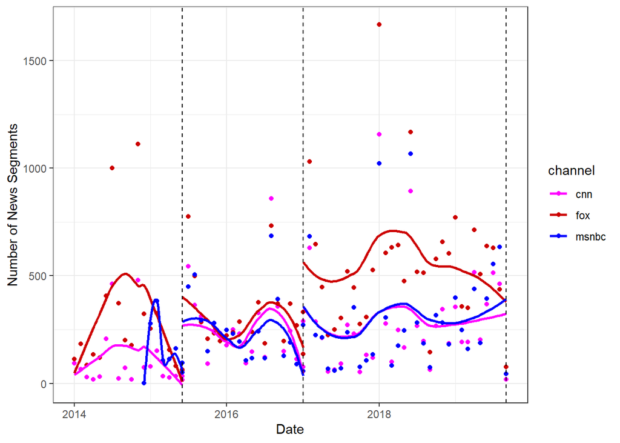

```r
line_data <-
  document_topics %>%
  group_by(time) %>%
  summarize(line_date = max(floor_date(ymd(date), "month")))


document_topics %>%
  mutate(month = floor_date(ymd(date), "month")) %>%
  group_by(month, channel, time) %>%
  summarize(num_segments = n()) %>%
  ggplot(aes(x = month, y = num_segments, color = channel)) +
  geom_point() +
  geom_smooth(aes(group = interaction(channel, time)), se = F) +
  scale_color_manual(values = c("magenta", "red3", "blue")) +
  geom_vline(data = line_data, aes(xintercept = line_date), linetype = "dashed") +
  labs(x = "Date", y = "Number of News Segments")
```

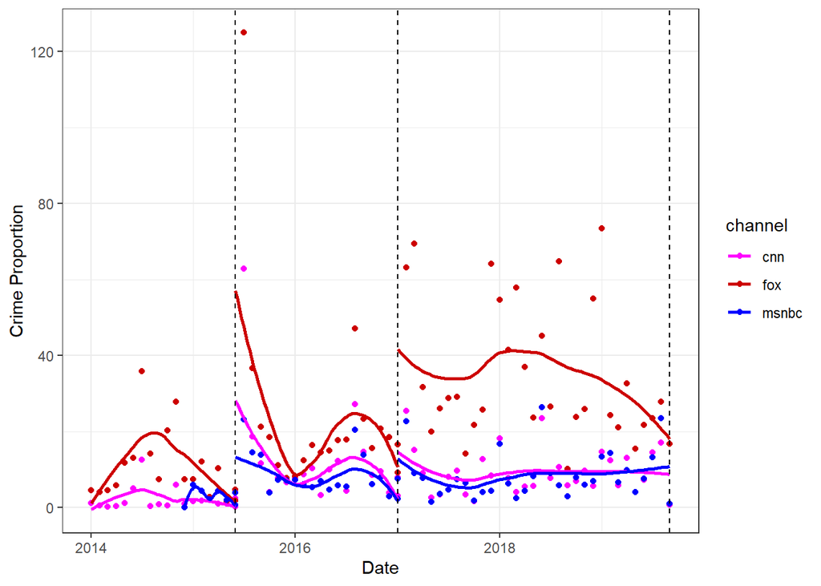

```r
#Crime Plot
document_topics %>%
  select(Topic1, Topic3, date, channel, time) %>%
  mutate(month = floor_date(ymd(date), "month")) %>%
  group_by(month, channel, time) %>%
  summarize(crime_prop = sum(Topic1, Topic3)) %>%
  ggplot(aes(x = month, y = crime_prop, color = channel)) +
  geom_point() +
  geom_smooth(aes(group = interaction(channel, time)), se = F) +
  scale_color_manual(values = c("magenta", "red3", "blue")) +
  geom_vline(data=line_data, aes(xintercept = line_date), linetype = "dashed") +
  labs(x = "Date", y = "Crime Proportion")
```

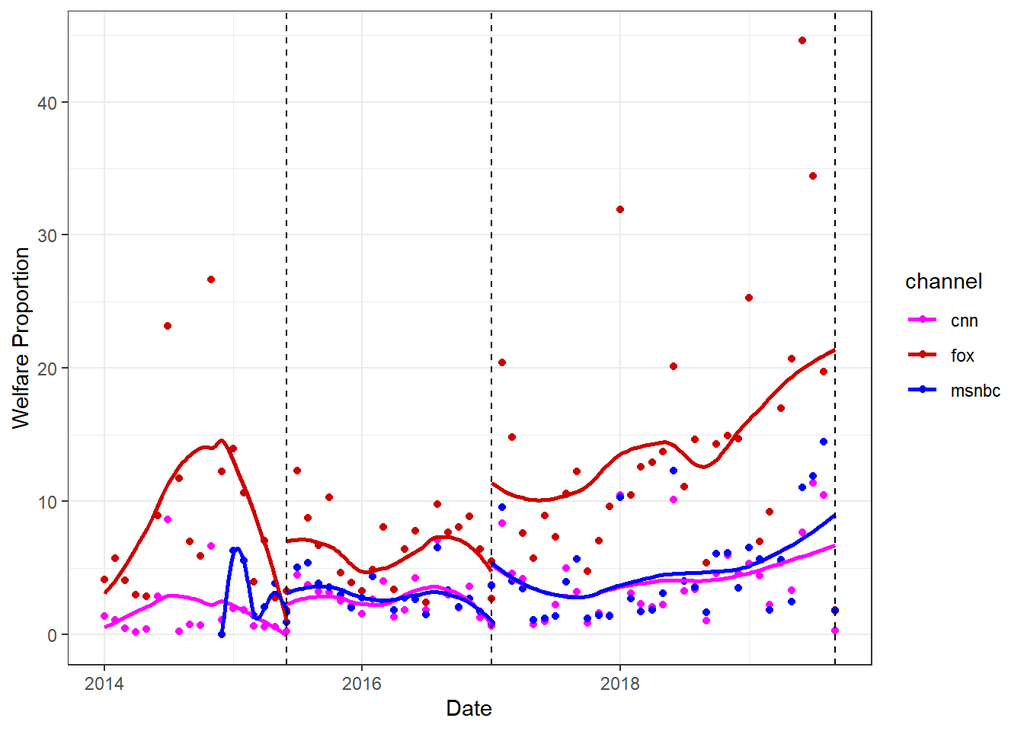

```r
#Welfare Plot
document_topics %>%
  select(Topic13, date, channel, time) %>%
  mutate(month = floor_date(ymd(date), "month")) %>%
  group_by(month, channel, time) %>%
  summarize(welfare_prop = sum(Topic13)) %>%
  ggplot(aes(x = month, y = welfare_prop, color = channel)) +
  geom_point() +
  geom_smooth(aes(group = interaction(channel, time)), se=F) +
  scale_color_manual(values = c("magenta", "red3", "blue")) +
  geom_vline(data = line_data, aes(xintercept = line_date), linetype = "dashed") +
  labs(x = "Date", y = "Welfare Proportion")
```

## Table 4

this model does not include the daily data

```r
Segment_Info <-
  document_topics %>%
  mutate(month = floor_date(ymd(date), "month")) %>%
  group_by(month, channel, time) %>%
  summarize(num_segments = n(), welfare_prop = sum(Topic13), crime_prop = sum(Topic1, Topic3)) %>%
  mutate(month_of_year = month(month)) %>%
  inner_join(reporting_data, join_by(month == date))
table_4_model <- lm(search_interest ~ num_segments + welfare_prop + crime_prop + Is_Trump + month + month_of_year, data=Segment_Info)


stargazer(table_4_model, type = "text")
```

```
##
## ===============================================
##                         Dependent variable:
##                     ---------------------------
##                           search_interest
## -----------------------------------------------
## num_segments                 0.019***
##                               (0.004)
##
## welfare_prop                  -0.082
##                               (0.144)
##
## crime_prop                    -0.007
##                               (0.049)
##
## Is_Trump                     17.958***
##                               (2.282)
##
## month                         -0.002
##                               (0.002)
##
## month_of_year                -0.924***
##                               (0.173)
##
## Constant                     77.784**
##                              (32.735)
##
## -----------------------------------------------
## Observations                    202
## R2                             0.654
## Adjusted R2                    0.643
## Residual Std. Error      7.977 (df = 195)
## F Statistic           61.360*** (df = 6; 195)
## ===============================================
## Note:               *p<0.1; **p<0.05; ***p<0.01
```

```r
daily_info <- read_csv("data/gt_report_daily.csv")
```

```
## ──────────────────────────────────────────────────────── Delimiter: "," dbl
## (3): ...1, search, search_adj date (1): date
```

```r
Segment_Info_Daily <-
  document_topics %>%
  mutate(Is_Trump = (date >= "2017-01-20")) %>%
  group_by(date, channel, time, Is_Trump) %>%
  mutate(date = as.Date(date, "%Y-%m-%d")) %>%
  summarize(num_segments = n(), welfare_prop = sum(Topic13), crime_prop = sum(Topic1, Topic3)) %>%
  mutate(month_of_year = as.factor(month(date)), day_of_week = as.factor(wday(date))) %>%
  inner_join(daily_info, join_by(date == date))
table_4_model_daily <- lm(search_adj ~ num_segments + welfare_prop + crime_prop + Is_Trump + date + month_of_year + day_of_week, data=Segment_Info_Daily)

stargazer(table_4_model_daily, type = "text")
```

```
##
## ===============================================
##                         Dependent variable:
##                     ---------------------------
##                             search_adj
## -----------------------------------------------
## num_segments                 0.203***
##                               (0.027)
##
## welfare_prop                   0.934
##                               (0.814)
##
## crime_prop                     0.277
##                               (0.325)
##
## Is_Trump                     20.280***
##                               (1.088)
##
## date                         -0.003***
##                               (0.001)
##
## month_of_year2                -0.963
##                               (1.273)
##
## month_of_year3              -10.449***
##                               (1.290)
##
## month_of_year4              -13.915***
##                               (1.298)
##
## month_of_year5              -13.099***
##                               (1.288)
##
## month_of_year6               -8.141***
##                               (1.276)
##
## month_of_year7              -10.963***
##                               (1.251)
##
## month_of_year8              -12.669***
```

[output cut: 28 more lines]

```
##
## day_of_week2                 -2.462**
##                               (1.009)
##
## Constant                    107.553***
##                              (15.956)
##
## -----------------------------------------------
## Observations                   5,053
## R2                             0.268
## Adjusted R2                    0.265
## Residual Std. Error     19.209 (df = 5030)
## F Statistic          83.795*** (df = 22; 5030)
## ===============================================
## Note:               *p<0.1; **p<0.05; ***p<0.01
```

# Extension

We are looking at the correlation between media coverage of the Mexican border crisis and migrants being apprehended and expelled at the border during the time period of 2014-2019.

## Download Border Data

```r
border_migrant_data <- read_csv("data/border_migrant_data.csv")
```

## Graph Border Apprehensions Over Time

This graph shows the amount of people apprehended at the border during both the Trump and Obama administrations.

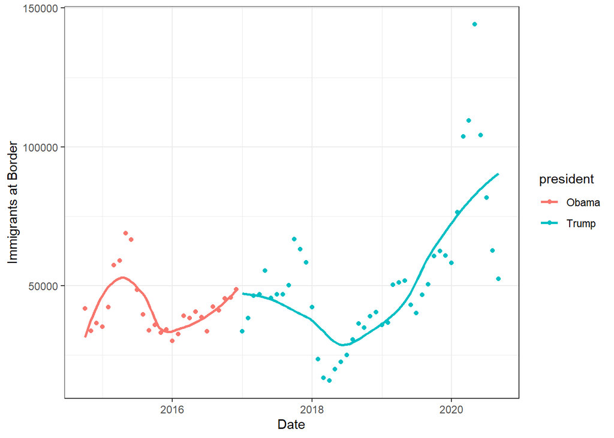

```r
border_migrant_data <- border_migrant_data %>%
  mutate(date = parse_date(Date, "%Y-%m")) %>%
  mutate(president = ifelse(year(date) < 2017, "Obama", "Trump"))

border_migrant_data %>%
  ggplot(aes(x = date, y = Number, color = president)) +
  geom_point() +
  geom_smooth(se = F) +
  labs(x = "Date", y = "Immigrants at Border")
```

## Media Coverage Graph

We graph the same media coverage graph as before, but looking at Topic 6 as this is the topic that discusses the Mexican border crisis. We obtain similar results to the above graphs: the border proportion goes up during the Trump administration and fox news discusses it the most. We can conclude from this that during the Trump administration the number of people being apprehended and expelled at the border increased, as did media coverage of the Mexican border crisis

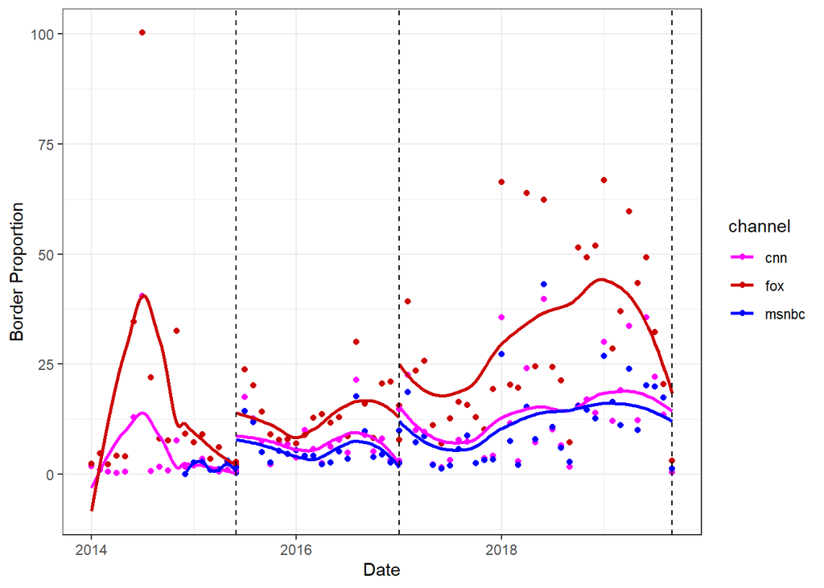

```r
document_topics %>%
  mutate(month = floor_date(ymd(date), "month")) %>%
  group_by(time, channel, month) %>%
  summarise(border_prop = sum(Topic6)) %>%
  ggplot(aes(x = month, y = border_prop, color = channel)) +
  geom_point() +
  geom_smooth(aes(group = interaction(channel, time)), se = F) +
  scale_color_manual(values = c("magenta", "red3", "blue")) +
  geom_vline(data = line_data, aes(xintercept = line_date), linetype = "dashed") +
  labs(x = "Date", y = "Border Proportion")
```

## Graphs Mapped Together

We expected to see an obvious correlation between the number of migrants apprehended at the border and media coverage, but it seems to be the opposite.

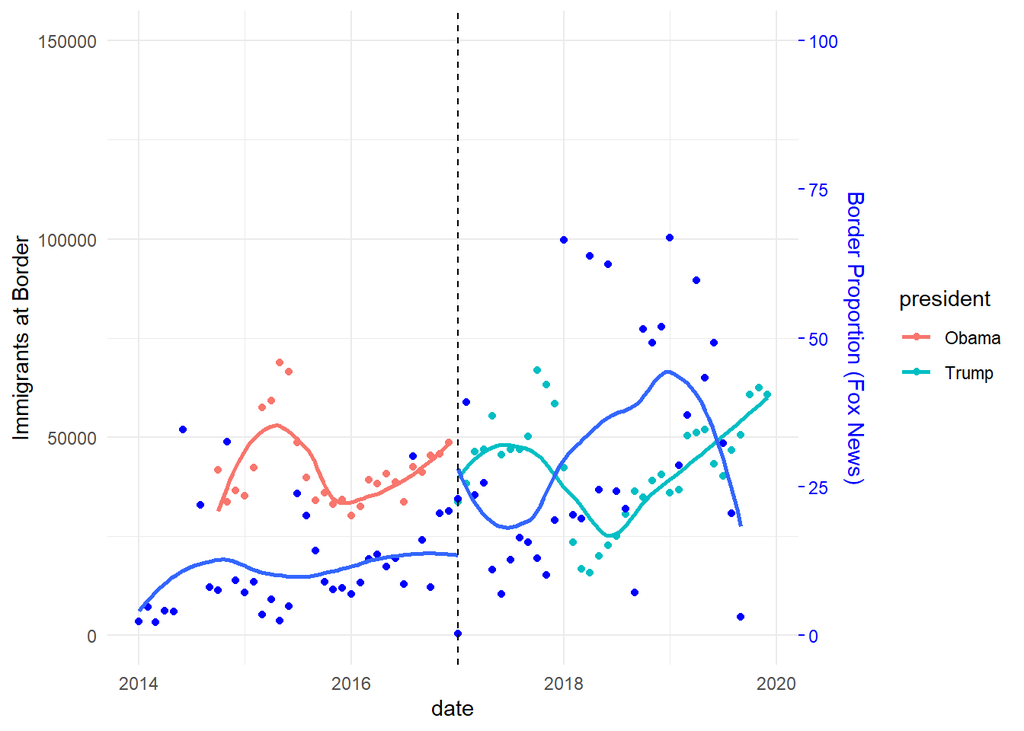

```r
migrant_plot_data <- border_migrant_data %>%
  filter(year(date) < 2020)
documents_plot_data <- document_topics %>%
  filter(channel == "fox") %>%
  mutate(month = floor_date(ymd(date), "month")) %>%
  mutate(time = ifelse(date <= "2017-01-01", "pre", "post")) %>%
  group_by(time, channel, month) %>%
  summarise(border_prop = sum(Topic6))
line_plot_data <- line_data %>%
  filter(line_date == "2017-01-01")

ggplot() +
  geom_point(data = migrant_plot_data, aes(x = date, y = Number, color = president)) +
  geom_smooth(data = migrant_plot_data, aes(x = date, y = Number, color = president),
              se = FALSE) +
  scale_y_continuous(name = "Number", limits = c(0, 150000)) +
  geom_point(data = documents_plot_data,  aes(x = month, y = border_prop * 1500, group = time),
             color = "blue") +
  geom_smooth(data = documents_plot_data, aes(x = month, y = border_prop * 1500, group = time),
              se = FALSE, inherit.aes = FALSE) +
  geom_vline(data = line_plot_data, aes(xintercept = line_date), linetype = "dashed") +
  scale_y_continuous(
    name = "Immigrants at Border",
    limits = c(0, 150000),
    sec.axis = sec_axis(~./1500, name = "Border Proportion (Fox News)")
  ) +
  theme_minimal() +
  theme(
    axis.title.y.right = element_text(color = "blue"),
    axis.text.y.right = element_text(color = "blue"),
    axis.ticks.y.right = element_line(color = "blue"))
```

## Regression

```r
migrant_model_info <- document_topics %>%
  mutate(Is_Trump = (date >= "2017-01-20")) %>%
  group_by(channel, date, Is_Trump) %>%
  mutate(date = as.Date(date, "%Y-%m-%d")) %>%
  summarise(num_segs = n(), border_prop = sum(Topic6)) %>%
  mutate(month_of_year = as.factor(month(date))) %>%
  inner_join(border_migrant_data, join_by(date == date))
migrant_model <- lm(border_prop ~ Is_Trump + Number, data = migrant_model_info)
stargazer(migrant_model, type = "text", digits = 8)
```

```
##
## ===============================================
##                         Dependent variable:
##                     ---------------------------
##                             border_prop
## -----------------------------------------------
## Is_Trump                   0.39839870***
##                            (0.13915790)
##
## Number                      0.00000087
##                            (0.00000619)
##
## Constant                    0.34480230
##                            (0.27686510)
##
## -----------------------------------------------
## Observations                    149
## R2                          0.05315544
## Adjusted R2                 0.04018496
## Residual Std. Error    0.84146540 (df = 146)
## F Statistic         4.09818800** (df = 2; 146)
## ===============================================
## Note:               *p<0.1; **p<0.05; ***p<0.01
```